# CSC 444 Data Visualization

November 10 2022

## Agenda

- What is multidimensional data?
- Strategies for Multidimensional data visualization:
  - direct visualization
  - projections

## Multidimensional data

## Multidimensional data

Real data is often high-dimensional (i.e. contain more than 3 features) – visualizations can help understand this type of data.

“For human perception, the data must be represented in a low-dimensional space, usually of two or three dimensions”

[(Dzemyda, Kurasova, & Zilinskas, 2012)](https://www.researchgate.net/profile/Gintautas-Dzemyda/publication/279344154_Springer_Optimization_and_Its_Applications/links/56c5efd208ae408dfe4ca176/Springer-Optimization-and-Its-Applications.pdf)

## Strategy: Direct Visualization

## Direct Visualization

“The direct visualization methods do not have any defined formal mathematical criterion for estimating the visualization quality”

[(Dzemyda, Kurasova, & Zilinskas, 2012)](https://www.researchgate.net/profile/Gintautas-Dzemyda/publication/279344154_Springer_Optimization_and_Its_Applications/links/56c5efd208ae408dfe4ca176/Springer-Optimization-and-Its-Applications.pdf)

Example: Scatter plot matrix

## Scatter plot matrix

- A grid (or matrix) of scatterplots showing bivariate relationships – histograms often accompany the scatterplots showing the distribution of values for individual variables.

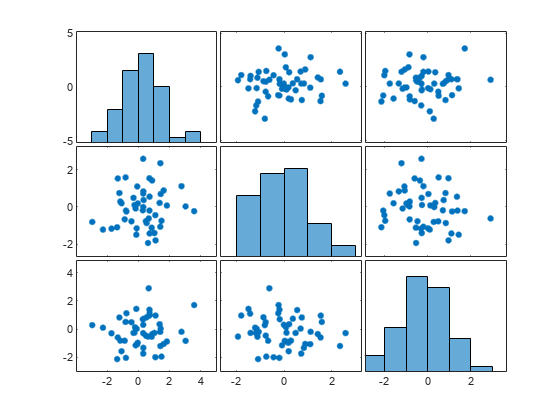

## Case Study: McDonald’s Menu Items

## The data

We will be using the [Nutrition Facts for McDonald’s Menu](https://www.kaggle.com/datasets/mcdonalds/nutrition-facts) dataset which contains a number of different variables/features for each menu item.

You can find the [data on GitHub](https://github.com/picoral/csc-444-data/blob/main/mcdonalds_menu.csv).

## Histogram Building

We will first create a histogram, since we already built many scatterplots before. For that, we need to use the following transforms:

- Extent Transform: to calculate the min and max values of a variable
- Bin Transform: to calculate bins to place each observation

We then count how many observations for bins.

Download starter project

## Extent Transform

We will read the data in and use an [extent transform](https://vega.github.io/vega/docs/transforms/extent/) to calculate the min and max values of the `calories` variable. We will save the results of the transform to a signal called `calories_max_min`

```javascript
data: [
  {
    name: "menu",
    url: "https://raw.github...mcdonalds_menu.csv",
    format: { type: "csv"},
    transform: [
      {
        type: "extent",
        field: "calories",
        signal: "calories_max_min"
      }
    ]
  }
]
```

## Extend Transform

You can accessed the values from the JavaScript console in your browser.

```javascript
view.signal("calories_max_min");
```

## Bin Transform

We then use a [bin transform](https://vega.github.io/vega/docs/transforms/bin/) with the signal we created to calculate bins.

```javascript
{
  type: "bin",
  signal: "bins",
  field: "calories",
  extent: { signal: "calories_max_min" },
  maxbins: 20

}
```

Two variables are added to the data: `bin0` and `bin1` – use `view.data("menu");` on the JavaScript console to inspect the data.

## Bins

Let’s now create a new data set where we can how many observations per bin.

```javascript
{
  name: "calories_bins",
  source: "menu",
  transform: [
    {
      type: "aggregate",
      groupby: ["bin0", "bin1"]
    }
  ]
}
```

Inspect the new data set using `view.data("calories_bins");`

## Scales

```javascript
scales: [
  {
    name: "xScale",
    type: "linear",
    bins: { signal: "bins" },
    domain: { signal: "[bins.start, bins.stop]" },
    range: "width"

  },
  {
    name: "yScale",
    type: "linear",
    domain: { data: "calories_bins", field: "count" },
    range: "height"
  }
],
```

## Marks

```javascript
marks: [
  {
    type: "rect",
    from: { data: "calories_bins" },
    encode: {
      enter: {
        x: { field: "bin0", scale: "xScale" },
        x2: { field: "bin1", scale: "xScale" },
        y: { field: "count", scale: "yScale" },
        y2: { value: 0, scale: "yScale" }
      }
    }
  }
]
```